# Lab 14 - Web Scraping

Stat 133

**General Instructions**

- Use the template file `lab14-template.qmd` to answer the questions.
- Rename this file as `lab14-first-last.qmd`, where `first` and `last` are your first and last names (e.g. `lab14-gaston-sanchez.qmd`).
- Make sure the YAML header in your `qmd` files includes `embed-resources: true`.
- Submit both your qmd and HTML files to the corresponding assignment submission in bCourses.
- Please note that if you submit the incorrect files you will receive no credit.

# 1 Intro to Books to scrape

Today’s lab is inspired by a [tutorial](https://betterdatascience.com/r-web-scraping/) on Better Data Science. We’re going to work with [Books to Scrape](http://books.toscrape.com/index.html), a website built to practice scraping.

**Looking at source code**

Before we start, take a look at the source code for Books to Scrape. What kind of data is there? What might be useful to scrape?

#### 1.0.0.1 Your Answer (below this line):

## 1.1 Importing HTML file

We can import the HTML file for the webpage by simply using `read_html()`.

```r
url <- 'http://books.toscrape.com/catalogue/category/books_1/index.html'
book_html <- read_html(url)
```

# 2 Scraping Books to Scrape

Now that we have the HTML file loaded into R, we can start to scrape some information from the webpage.

In class, you learned how to scrape using the `xpath` argument in `html_elements()`. Here, we’ll use the `css` argument. Feel free to use whichever you prefer in your code.

## 2.1 Scraping Book Genres

First, let’s look into the book genres. Looking at the HTML document, it appears that all genres are held in a link that is contained in an element with class ‘side_categories’. To get all the genres, we can start by looking for HTML elements with class ‘side_categories’. Then, we look for link elements (i.e. ‘a’ elements) within ‘side_categories’.

To retrieve elements of a certain class, we put a period in front of the class name, as shown below.

```r
book_html %>%
  html_elements('.side_categories') %>%
  html_elements('a') %>%
  html_text2()
```

```
 [1] "Books"              "Travel"             "Mystery"
 [4] "Historical Fiction" "Sequential Art"     "Classics"
 [7] "Philosophy"         "Romance"            "Womens Fiction"
[10] "Fiction"            "Childrens"          "Religion"
[13] "Nonfiction"         "Music"              "Default"
[16] "Science Fiction"    "Sports and Games"   "Add a comment"
[19] "Fantasy"            "New Adult"          "Young Adult"
[22] "Science"            "Poetry"             "Paranormal"
[25] "Art"                "Psychology"         "Autobiography"
[28] "Parenting"          "Adult Fiction"      "Humor"
[31] "Horror"             "History"            "Food and Drink"
[34] "Christian Fiction"  "Business"           "Biography"
[37] "Thriller"           "Contemporary"       "Spirituality"
[40] "Academic"           "Self Help"          "Historical"
[43] "Christian"          "Suspense"           "Short Stories"
[46] "Novels"             "Health"             "Politics"
[49] "Cultural"           "Erotica"            "Crime"
```

## 2.2 Scraping Book Information

Next, let’s scrape information about the books on the website. Note that we cannot see all the books on one page. Each page of the website shows at most twenty books. This will be important later.

We’ll start by taking a look at the structure of book titles on a webpage (screenshot below).

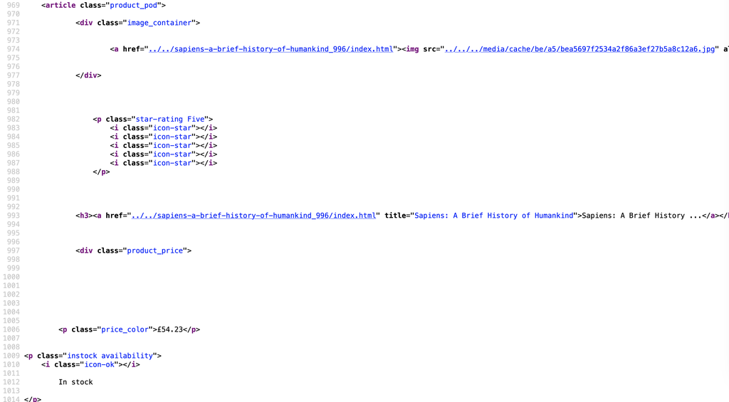

Book Info

From this screenshot, we can get an idea of how data is stored for each of the books. We can leverage the above structure to scrape data from our html file.

### 2.2.1 Scraping Title

The title for each book is contained in a header (‘h3’) with a link (‘a’). With this information, we can perform a similar operation as with genres.

```r
book_html %>%
  html_elements('h3') %>%
  html_elements('a') %>%
  html_text2()
```

```
 [1] "A Light in the ..."
 [2] "Tipping the Velvet"
 [3] "Soumission"
 [4] "Sharp Objects"
 [5] "Sapiens: A Brief History ..."
 [6] "The Requiem Red"
 [7] "The Dirty Little Secrets ..."
 [8] "The Coming Woman: A ..."
 [9] "The Boys in the ..."
[10] "The Black Maria"
[11] "Starving Hearts (Triangular Trade ..."
[12] "Shakespeare's Sonnets"
[13] "Set Me Free"
[14] "Scott Pilgrim's Precious Little ..."
[15] "Rip it Up and ..."
[16] "Our Band Could Be ..."
[17] "Olio"
[18] "Mesaerion: The Best Science ..."
[19] "Libertarianism for Beginners"
[20] "It's Only the Himalayas"
```

It appears that books with longer titles are truncated. However, the full book title is an attribute of the link. If we want to get the full title, we can use `html_attr()` to retrieve the ‘title’ attribute.

```r
book_html %>%
  html_elements('h3') %>%
  html_elements('a') %>%
  html_attr('title')
```

```
 [1] "A Light in the Attic"
 [2] "Tipping the Velvet"
 [3] "Soumission"
 [4] "Sharp Objects"
 [5] "Sapiens: A Brief History of Humankind"
 [6] "The Requiem Red"
 [7] "The Dirty Little Secrets of Getting Your Dream Job"
 [8] "The Coming Woman: A Novel Based on the Life of the Infamous Feminist, Victoria Woodhull"
 [9] "The Boys in the Boat: Nine Americans and Their Epic Quest for Gold at the 1936 Berlin Olympics"
[10] "The Black Maria"
[11] "Starving Hearts (Triangular Trade Trilogy, #1)"
[12] "Shakespeare's Sonnets"
[13] "Set Me Free"
[14] "Scott Pilgrim's Precious Little Life (Scott Pilgrim #1)"
[15] "Rip it Up and Start Again"
[16] "Our Band Could Be Your Life: Scenes from the American Indie Underground, 1981-1991"
[17] "Olio"
[18] "Mesaerion: The Best Science Fiction Stories 1800-1849"
[19] "Libertarianism for Beginners"
[20] "It's Only the Himalayas"
```

### 2.2.2 Scraping Price

From the HTML file, we can see that the price of a product is contained in a paragraph(‘p’) with class ‘price_color’.

```r
book_html %>%
  html_elements('.price_color') %>%
  html_text2()
```

```
 [1] "£51.77" "£53.74" "£50.10" "£47.82" "£54.23" "£22.65" "£33.34" "£17.93"
 [9] "£22.60" "£52.15" "£13.99" "£20.66" "£17.46" "£52.29" "£35.02" "£57.25"
[17] "£23.88" "£37.59" "£51.33" "£45.17"
```

### 2.2.3 Scraping Stock

Similarly to price, stock is contained in a paragraph element with class ‘instock availability’. We only need to refer to ‘instock’.

```r
book_html %>%
  html_elements('.instock') %>%
  html_text2()
```

```
 [1] "In stock" "In stock" "In stock" "In stock" "In stock" "In stock"
 [7] "In stock" "In stock" "In stock" "In stock" "In stock" "In stock"
[13] "In stock" "In stock" "In stock" "In stock" "In stock" "In stock"
[19] "In stock" "In stock"
```

### 2.2.4 Scraping Ratings

Finally, ratings are a bit more complex. The rating is encoded as a set of icons, but the class of that set of icons changes depending on the rating. For example, a five-star rating is contained in an element with class ‘star-rating Five’. Therefore, we need to scrape the class of the rating rather than the value of the element.

```r
read_html(url) %>%
  html_elements('p.star-rating') %>%
  html_attr('class')
```

```
 [1] "star-rating Three" "star-rating One"   "star-rating One"
 [4] "star-rating Four"  "star-rating Five"  "star-rating One"
 [7] "star-rating Four"  "star-rating Three" "star-rating Four"
[10] "star-rating One"   "star-rating Two"   "star-rating Four"
[13] "star-rating Five"  "star-rating Five"  "star-rating Five"
[16] "star-rating Three" "star-rating One"   "star-rating One"
[19] "star-rating Two"   "star-rating Two"
```

However, we only want the last word of the above strings. We can use `str_remove()` to get ride of ‘star-rating’ in all our data.

```r
read_html(url) %>%
  html_elements('p.star-rating') %>%
  html_attr('class') %>%
  str_remove('star-rating ')
```

```
 [1] "Three" "One"   "One"   "Four"  "Five"  "One"   "Four"  "Three" "Four"
[10] "One"   "Two"   "Four"  "Five"  "Five"  "Five"  "Three" "One"   "One"
[19] "Two"   "Two"
```

### 2.2.5 Data Frame for Scraped Data

We can put all of the data we’ve scraped into a data frame to make it easier to work with.

```r
title <- book_html %>%
  html_elements('h3') %>%
  html_elements('a') %>%
  html_attr('title')

price <- book_html %>%
  html_elements('.price_color') %>%
  html_text2()

stock <- book_html %>%
  html_elements('.instock') %>%
  html_text2()

rating <- read_html(url) %>%
  html_elements('p.star-rating') %>%
  html_attr('class') %>%
  str_remove('star-rating ')

book_info <- data.frame(
  Title = title,
  Price = price,
  Stock = stock,
  Rating = rating
)
book_info
```

```
                                                                                            Title
1                                                                            A Light in the Attic
2                                                                              Tipping the Velvet
3                                                                                      Soumission
4                                                                                   Sharp Objects
5                                                           Sapiens: A Brief History of Humankind
6                                                                                 The Requiem Red
7                                              The Dirty Little Secrets of Getting Your Dream Job
8         The Coming Woman: A Novel Based on the Life of the Infamous Feminist, Victoria Woodhull
9  The Boys in the Boat: Nine Americans and Their Epic Quest for Gold at the 1936 Berlin Olympics
10                                                                                The Black Maria
11                                                 Starving Hearts (Triangular Trade Trilogy, #1)
12                                                                          Shakespeare's Sonnets
13                                                                                    Set Me Free
14                                        Scott Pilgrim's Precious Little Life (Scott Pilgrim #1)
```

[output cut: 27 more lines]

# 3 Your Turn: More Scraping

Now it’s your turn! There’s a lot left to be scraped on the website.

## 3.1 Scraping Across Genre

Scrape the information for books in three different genres (only the first page). Combine their information with into one data frame that also has a column for genre.

**Hint**

Use the url for a genre to scrape it’s data, i.e. use the url you get when you click on the genre link.

```r
# your code
```

## 3.2 Scraping Across Pages

The ‘Sequential Art’ genre has 75 books across four pages. Scrape the data for all Sequential Art books.

**Hint**

Use the url for each page. It may be useful to build a for loop.

```r
# your code
```

## 3.3 Scraping URLs

The tutorial mentioned above scrapes urls for each book using the following code:

```r
urls <- read_html(url) %>%
  html_nodes('.image_container') %>%
  html_nodes('a') %>%
  html_attr('href') %>%
  str_replace_all('../../../', '/')
```

How is this code scraping urls? Where is the url contained?

#### 3.3.0.1 Your answer (below this line):

## 3.4 What to do next?

Now we have an abundance of data on books being ‘sold’ on this website. As noted on Books to Scrape, the data themselves are randomly generated and therefore meaningless.

But suppose that you scraped data from a website that actually sells books. What kind of analysis would you do? What kind of plots would you make? What would the variables be?

**Note**

You do not need to actually do any analysis. Just explain what analysis you think would be interesting to perform.

#### 3.4.0.1 Your answer (below this line):